# UC business Analytics R programming Guide

Koji Mizumura

2019-04-01

This is a practice of [UC business analytics R programming guide](http://uc-r.github.io/).

# 1 Descrptive analytics

Descriptive methodologies focus on analyzing historic data of the purpose of identifying patterns or trends. Analytic techniques fall into this category are most often associated with exploratory data analysis which identifies central tendencies, variations, and distributional shapes. Descriptive methodologies can also search for underlying structures whithin data when no a *priori* knowledge about patterns and relationships are assumed.

This can include correlation analysis, exploratory factor analysis, principal component analysis, trend analyses, and cluster analysis. The following tutorial walk you through common forms of descriptive analytics.

1. Classical analyses
- [Numerical data descrptive statistics](http://uc-r.github.io/descriptives_numeric)
- Categorical data descriptive statistics
- Assumption of normality
- Assumption of homogeneity
- Assessing correlations
- Univariate statistical inference
- Multivariate statistical inference
- Bootstrapping for parameter estimates
2. Text mining
- Tidying text & word frequency
- Sentiment analysis
- Term vs Document frequency
- Word relationships
- Converting between tidy and non-tidy formats
3. Unsupervised learning

## 1.1 Classical analyses

### 1.1.1 [Numerical data descriptive statistics](http://uc-r.github.io/descriptives_numeric)

Descriptive statistics are the first piece of information used to understand and represent a dataset. There goal in essence, is to describe the main features of numerical and categorical information with simple summaries. These summaries can be presented with a single numeric measure, using summary tables, or via graphical representation. Here, I illustrate the most common forms of descriptive statistics for numerical data but keep in mind there are numerous ways to describe and illustrate key feature of data.

#### 1.1.1.1 tl;dr

This tutorial covers the key features we are initially interested in understanding for numerical data, to include:

- central tendency: what are the most typical values?
- variability:How do the values vary?
- shape: Are the values symmetrically or asymetrically distributed?
- outliers: Are there values that represent abnormalities in the data?
- visualization: We should understand these features of the data through statistics and visualization.

#### 1.1.1.2 Replication requirements

To illustrate ways to comute different summary statistics, and to visualize the data to provide understanding of these key features, I’ll demonstrate using this [data](https://github.com/bradleyboehmke/bradleyboehmke.github.io/blob/master/public/data/Baseball%20Salaries%202011.xlsx) which contains data on 843 MLB players in the 2011 season:

```r
readxl::read_xlsx("https://github.com/bradleyboehmke/bradleyboehmke.github.io/blob/master/public/data/Baseball%20Salaries%202011.xlsx")
```

In addition, the packages we will leverage include the following:

```r
library(outliers) # identidying and extracting outliers
library(ggplot2)  # for generating visualization
library(moments)  # for calculating the skew and kurtosis
```

# 2 Predictive analytics

## 2.1 Machine Learning

### 2.1.1 Preparing for regression problems

Machine learning is a very iterative process. If performed and interpreted correctly, we can have great confidence in our outcomes. If not, the results will be useless. Approaching machine learning correctly means approaching it strategically by spending our data wisely on learning and validation procedures, properly pre-processing variables, minimizing data leakage, tuning parameters and assessing model performance.

Before introducing specific algorithms, this tutorial introduces concepts that are commonly required in the supervised machine learning process and that you will see briskly covered in tutorieals that follow. This tutorial will prepare you with the fundamentals needed prior to applying supervised machine learning algorithms.

#### 2.1.1.1 tl;dr

Before introducing specific algorithms, this tutorial introduces concepts that you will see briskly covered in each chapter and are necessary for any type of supervised machine learning model:

1. Prerequisites: what you will need to reproduce the analysis in this tutorial

##### 2.1.1.1.1 Prerequisites

This tutorial leverages the following packages.

```r
library(rsample)
library(caret)
library(h2o)
library(dplyr)

# turn off progress bars
h2o.no_progress()

# launch h2o
h2o.init()
```

[output not shown]

To illustrate some of concepts we will use the Ames Housing data that has been included in the `AmesHousing` package and the employee attrition data that has been included in the `rsample` package. The housing data represents a continuous response variable (`Sale_Price`) along with 80 features (predictor variables) for 2930 homes in Ames, IA. Read more about this data [here](https://cran.r-project.org/web/packages/AmesHousing/AmesHousing.pdf). The attrition data represents a classification response variable (`Attrition`) with 30 features for 1470 employees. Read more about this data [here](https://www.ibm.com/communities/analytics/watson-analytics-blog/hr-employee-attrition/)

Throughout this tutorial, we will demonstrate approaches with the regular `df` data frame. However, since many of the supervised machine learning tutorials that we provide leverage `h2o`, we also show how to do some of the things with `h2o`. This requires your data to be in H2O object, which you can convert any data friame easily with `as.h2o`.

```r
# ames data
ames <- AmesHousing::make_ames()
ames.h2o <- as.h2o(ames)

# attrition data
churn <- rsample::attrition %>%
  mutate_if(is.ordered, factor, ordered=FALSE)
churn.h2o <- as.h2o(churn)
```

#### 2.1.1.2 Data splitting

##### 2.1.1.2.1 Spending our data wisely

A major goal of the machine learning process is to find an algorithm $f(x)$ that most accurately predicts future values $(y)$ based on a set of inputs $(x)$. In other words, we want an algorithm that not only fits well to our past data, but more importantly, one that predicts a future outcome accurately. This is called the generalizability of our algorithm. How we “spend” our data will help us understand how well our algorithm generalizes to unseen data.

To provide an accurate understanding of the generalizability of our fina optimal model, we split our data into training and test data sets.

- **Training set**: these data are used to train our algorithms and tune hyper-parameters.
- **Test set**: having chosen a final model, these data are used to estimate its prediction error (generalization error). These data should not be used *during model training*

Given a fixed amount of data, typical recommendations for splitting your data into training-testing splits include 60% (training) - 40% (testing), 70%-30%, or 80%-20%. Generally speaking, these are appropriate guidelines to follow; however, it is good to keep in mind that as your overall data set gets smaller,

- Spending too much in training ($>80%$) won’t allow us to get a good assessment of predictive performance. We may find a model that fits the training data very well, but is not generalizable (overfitting),
- sometimes too much spent in testing ($>40%$) won’t allow us to get a good assessment of model parameters.

Typically, we are lacking in the size of our data here, so a 70-30 split is often sufficinet. The two most common ways of splittin data include **simple random sampling** and **stratified sampling**.

##### 2.1.1.2.2 Simple random sampling

The simplest way to split the data into training and test sets is to take a simple random sample. This does not control for any data attributes, such as the percentage of data in the quantiles in your response variable ($y$). There are multiple ways to split our data. Here we show four options to produce a 70-30 split (note that setting the seed value allows you to reproduce your randomized splits):

```r
# base R
df <- ames
df.h2o <- ames.h2o

set.seed(123)
df
```

```
## # A tibble: 2,930 x 81
##    MS_SubClass MS_Zoning Lot_Frontage Lot_Area Street Alley Lot_Shape
##    <fct>       <fct>            <dbl>    <int> <fct>  <fct> <fct>
##  1 One_Story_~ Resident~          141    31770 Pave   No_A~ Slightly~
##  2 One_Story_~ Resident~           80    11622 Pave   No_A~ Regular
##  3 One_Story_~ Resident~           81    14267 Pave   No_A~ Slightly~
##  4 One_Story_~ Resident~           93    11160 Pave   No_A~ Regular
##  5 Two_Story_~ Resident~           74    13830 Pave   No_A~ Slightly~
##  6 Two_Story_~ Resident~           78     9978 Pave   No_A~ Slightly~
##  7 One_Story_~ Resident~           41     4920 Pave   No_A~ Regular
##  8 One_Story_~ Resident~           43     5005 Pave   No_A~ Slightly~
##  9 One_Story_~ Resident~           39     5389 Pave   No_A~ Slightly~
## 10 Two_Story_~ Resident~           60     7500 Pave   No_A~ Regular
## # ... with 2,920 more rows, and 74 more variables: Land_Contour <fct>,
## #   Utilities <fct>, Lot_Config <fct>, Land_Slope <fct>,
## #   Neighborhood <fct>, Condition_1 <fct>, Condition_2 <fct>,
## #   Bldg_Type <fct>, House_Style <fct>, Overall_Qual <fct>,
## #   Overall_Cond <fct>, Year_Built <int>, Year_Remod_Add <int>,
## #   Roof_Style <fct>, Roof_Matl <fct>, Exterior_1st <fct>,
## #   Exterior_2nd <fct>, Mas_Vnr_Type <fct>, Mas_Vnr_Area <dbl>,
## #   Exter_Qual <fct>, Exter_Cond <fct>, Foundation <fct>, Bsmt_Qual <fct>,
## #   Bsmt_Cond <fct>, Bsmt_Exposure <fct>, BsmtFin_Type_1 <fct>,
## #   BsmtFin_SF_1 <dbl>, BsmtFin_Type_2 <fct>, BsmtFin_SF_2 <dbl>,
## #   Bsmt_Unf_SF <dbl>, Total_Bsmt_SF <dbl>, Heating <fct>,
## #   Heating_QC <fct>, Central_Air <fct>, Electrical <fct>,
## #   First_Flr_SF <int>, Second_Flr_SF <int>, Low_Qual_Fin_SF <int>,
## #   Gr_Liv_Area <int>, Bsmt_Full_Bath <dbl>, Bsmt_Half_Bath <dbl>,
## #   Full_Bath <int>, Half_Bath <int>, Bedroom_AbvGr <int>,
## #   Kitchen_AbvGr <int>, Kitchen_Qual <fct>, TotRms_AbvGrd <int>,
## #   Functional <fct>, Fireplaces <int>, Fireplace_Qu <fct>,
## #   Garage_Type <fct>, Garage_Finish <fct>, Garage_Cars <dbl>,
## #   Garage_Area <dbl>, Garage_Qual <fct>, Garage_Cond <fct>,
## #   Paved_Drive <fct>, Wood_Deck_SF <int>, Open_Porch_SF <int>,
## #   Enclosed_Porch <int>, Three_season_porch <int>, Screen_Porch <int>,
## #   Pool_Area <int>, Pool_QC <fct>, Fence <fct>, Misc_Feature <fct>,
## #   Misc_Val <int>, Mo_Sold <int>, Year_Sold <int>, Sale_Type <fct>,
## #   Sale_Condition <fct>, Sale_Price <int>, Longitude <dbl>,
## #   Latitude <dbl>
```

```r
index   <- sample(1:nrow(df), round(nrow(df) * 0.7))
train_1 <- df[index, ]
test_1  <- df[-index, ]

# caret package
set.seed(123)
index2  <- createDataPartition(df$Sale_Price, p = 0.7, list = FALSE)
train_2 <- df[index2, ]
test_2  <- df[-index2, ]

# rsample package
set.seed(123)
split_1  <- initial_split(df, prop = 0.7)
train_3  <- training(split_1)
test_3   <- testing(split_1)

# h2o package
split_2 <- h2o.splitFrame(df.h2o, ratios = 0.7, seed = 123)
train_4 <- split_2[[1]]
test_4  <- split_2[[2]]
```

Since this sampling approach will randomly sample across the distribution of $y$ (`Sale_Price`), you will typically result in a similar distribution betwen your training and test sets as iilustrated below.

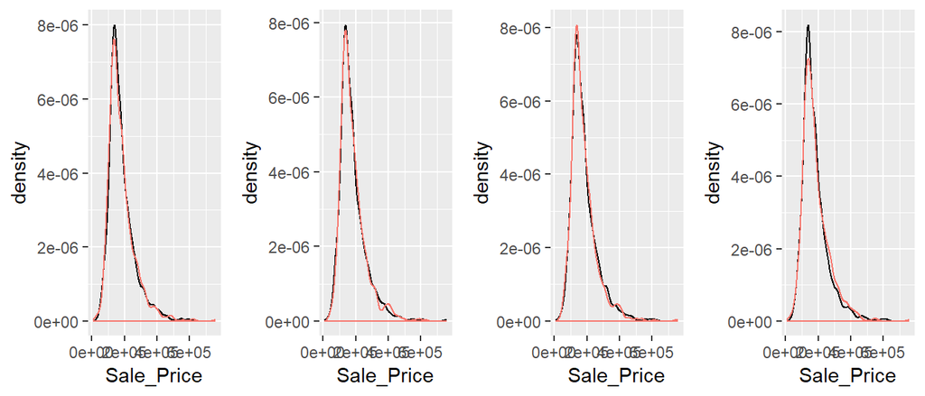

```r
# base R
p1 <- ggplot()+
  geom_density(data=train_1, aes(Sale_Price), show.legend = FALSE)+
  geom_density(data=test_1, aes(x=Sale_Price, col="red"),show.legend = FALSE)

# caret
p2 <- ggplot()+
  geom_density(data=train_2, aes(Sale_Price),show.legend = FALSE)+
  geom_density(data=test_2, aes(x=Sale_Price, col="red"),show.legend = FALSE)

# sample
p3 <- ggplot()+
  geom_density(data=train_3, aes(Sale_Price),show.legend = FALSE)+
  geom_density(data=test_3, aes(x=Sale_Price, col="red"),show.legend = FALSE)

# h2o

p4 <- ggplot()+
  geom_density(data=as_tibble(train_4), aes(Sale_Price),show.legend = FALSE)+
  geom_density(data=as_tibble(test_4), aes(x=Sale_Price, col="red"),show.legend = FALSE)

gridExtra::grid.arrange(p1,p2,p3,p4,
                        nrow=1)
```

##### 2.1.1.2.3 Stratified sampling

However, if we want to explictly control our sampling so that our training and test sets have similar $y$ distributions, we can use **stratified sampling**. This is more common with classification problems where the response variable may be imbalanced (90% of observations with response “Yes” and 10% with response “No”). However, we can also apply to regression problems for data sets that have a small sample size and where the response variable deviates strongly from *normality*.

With a continuous response variable, stratified sampling will break y down into quantiles and randomly sample from each quantile. Consequently, this will help ensure a balanced representation of the response distribution in both the training and test sets.

The easiest way to perform stratified sampling on a response variable is to use the `rsample` package, where you specify the response variable to `strata` fy. The following illustrates that in our original employee attrition data we have an imbalanced response (No: 84%, Yes:16%). By enforcing stratified sampling both our training and testing sets have approximiately equal response distributions.

```r
# original response distribution
table(churn$Attrition) %>% prop.table()
```

```
##
##        No       Yes
## 0.8387755 0.1612245
```

```r
# stratified sampling with the rsample package
set.seed(123)
split_strat <- initial_split(churn, prop=0.7, strata = "Attrition")
train_strat <- training(split_strat)
test_strat <- testing(split_strat)

# consistent response ratio between train & test
table(train_strat$Attrition) %>% prop.table()
```

```
##
##       No      Yes
## 0.838835 0.161165
```

```r
table(test_strat$Attrition) %>% prop.table()
```

```
##
##        No       Yes
## 0.8386364 0.1613636
```

#### 2.1.1.3 Feature engineering

**Feature engineering** generally refers to the process of adding, deleting and transforming the variables to be applied to your machine learning algorithms.

Feature engineering is a siginificant process and requires you to spend substantial time understanding your data… or as Leo Breiman said “live with your data before you plunge into modeling”

Although this guide is primarily concerned with machine learning algorithms, feature engineering can make or break an algorithm’s predictive ability. We will not cover all the potential ways of implementing feature engineering; however, we will cover a few fundamental pre-processing tasks that can significantly improve modeling performance.

1. One-hot encoding

Many models require all variables to be numeric. Consequently, we need to transform any categorical variables into numeric representation so that these algorithms can compute. Some packages automate this process (i.e., `h2o`, `glm`, `caret`) while others do not (i.e., `glmnet`, `keras`). Furthermore, there are many ways to encode categorical variables as numeric representation (i.e., one-hot, orinal, binary, sum, Helmert).

The most common is refered to as one-hot encoding, where we transpose our categorical variables so that each level of the feature is represented as a boolean value. For example, one-hot encoding variable `x` in the following:

```r
sample <- tibble::tribble(
  ~id, ~x,
  1,"a",
  2,"c",
  3,"b",
  4,"c",
  5,"c",
  6,"a",
  7,"b",
  8,"c"
)

sample %>%
  mutate(x=as.factor(x))
```

```
## # A tibble: 8 x 2
##      id x
##   <dbl> <fct>
## 1     1 a
## 2     2 c
## 3     3 b
## 4     4 c
## 5     5 c
## 6     6 a
## 7     7 b
## 8     8 c
```

If you need to manually implement one-hot encoding yourself, you can do that with `caret::dummyVars`. Sometimes you many have a feature level with very few observations and all these observations show up in the test set but not the training set. The benefit of using `dummyVars` on the full data set and then applying the result to both the train and test data sets is that it will guarantee that the same features are represented in both the train and test data.

```r
# full rank one-hot encode - recommended for generalized linear models and neural networks.

library(caret)
full_rank <- dummyVars(~., data = df, fullRank = TRUE)
train_oh <- predict(full_rank, train_1)
test_oh <- predict(full_rank, test_1)

train_1 %>% head()
```

```
## # A tibble: 6 x 81
##   MS_SubClass MS_Zoning Lot_Frontage Lot_Area Street Alley Lot_Shape
##   <fct>       <fct>            <dbl>    <int> <fct>  <fct> <fct>
## 1 Two_Story_~ Resident~           80    10400 Pave   No_A~ Regular
## 2 One_Story_~ Resident~            0    39384 Pave   No_A~ Slightly~
## 3 Duplex_All~ Resident~           87     9246 Pave   No_A~ Slightly~
## 4 One_Story_~ Resident~           66    12778 Pave   No_A~ Regular
## 5 One_Story_~ Resident~           64     7488 Pave   No_A~ Slightly~
## 6 One_Story_~ Resident~           78     7800 Pave   No_A~ Regular
## # ... with 74 more variables: Land_Contour <fct>, Utilities <fct>,
## #   Lot_Config <fct>, Land_Slope <fct>, Neighborhood <fct>,
## #   Condition_1 <fct>, Condition_2 <fct>, Bldg_Type <fct>,
## #   House_Style <fct>, Overall_Qual <fct>, Overall_Cond <fct>,
## #   Year_Built <int>, Year_Remod_Add <int>, Roof_Style <fct>,
## #   Roof_Matl <fct>, Exterior_1st <fct>, Exterior_2nd <fct>,
## #   Mas_Vnr_Type <fct>, Mas_Vnr_Area <dbl>, Exter_Qual <fct>,
## #   Exter_Cond <fct>, Foundation <fct>, Bsmt_Qual <fct>, Bsmt_Cond <fct>,
## #   Bsmt_Exposure <fct>, BsmtFin_Type_1 <fct>, BsmtFin_SF_1 <dbl>,
## #   BsmtFin_Type_2 <fct>, BsmtFin_SF_2 <dbl>, Bsmt_Unf_SF <dbl>,
## #   Total_Bsmt_SF <dbl>, Heating <fct>, Heating_QC <fct>,
## #   Central_Air <fct>, Electrical <fct>, First_Flr_SF <int>,
## #   Second_Flr_SF <int>, Low_Qual_Fin_SF <int>, Gr_Liv_Area <int>,
## #   Bsmt_Full_Bath <dbl>, Bsmt_Half_Bath <dbl>, Full_Bath <int>,
## #   Half_Bath <int>, Bedroom_AbvGr <int>, Kitchen_AbvGr <int>,
## #   Kitchen_Qual <fct>, TotRms_AbvGrd <int>, Functional <fct>,
## #   Fireplaces <int>, Fireplace_Qu <fct>, Garage_Type <fct>,
## #   Garage_Finish <fct>, Garage_Cars <dbl>, Garage_Area <dbl>,
## #   Garage_Qual <fct>, Garage_Cond <fct>, Paved_Drive <fct>,
## #   Wood_Deck_SF <int>, Open_Porch_SF <int>, Enclosed_Porch <int>,
## #   Three_season_porch <int>, Screen_Porch <int>, Pool_Area <int>,
## #   Pool_QC <fct>, Fence <fct>, Misc_Feature <fct>, Misc_Val <int>,
## #   Mo_Sold <int>, Year_Sold <int>, Sale_Type <fct>, Sale_Condition <fct>,
## #   Sale_Price <int>, Longitude <dbl>, Latitude <dbl>
```

```r
train_oh %>% as_tibble() %>% head()
```

```
## # A tibble: 6 x 308
##   MS_SubClass.One~ MS_SubClass.One~ MS_SubClass.One~ MS_SubClass.One~
##              <dbl>            <dbl>            <dbl>            <dbl>
## 1                0                0                0                0
## 2                0                0                0                0
## 3                0                0                0                0
## 4                0                0                0                0
## 5                0                0                0                0
## 6                0                0                0                0
## # ... with 304 more variables: MS_SubClass.Two_Story_1946_and_Newer <dbl>,
## #   MS_SubClass.Two_Story_1945_and_Older <dbl>,
## #   MS_SubClass.Two_and_Half_Story_All_Ages <dbl>,
## #   MS_SubClass.Split_or_Multilevel <dbl>, MS_SubClass.Split_Foyer <dbl>,
## #   MS_SubClass.Duplex_All_Styles_and_Ages <dbl>,
## #   MS_SubClass.One_Story_PUD_1946_and_Newer <dbl>,
## #   MS_SubClass.One_and_Half_Story_PUD_All_Ages <dbl>,
## #   MS_SubClass.Two_Story_PUD_1946_and_Newer <dbl>,
## #   MS_SubClass.PUD_Multilevel_Split_Level_Foyer <dbl>,
## #   MS_SubClass.Two_Family_conversion_All_Styles_and_Ages <dbl>,
## #   MS_Zoning.Residential_High_Density <dbl>,
## #   MS_Zoning.Residential_Low_Density <dbl>,
## #   MS_Zoning.Residential_Medium_Density <dbl>, MS_Zoning.A_agr <dbl>,
## #   MS_Zoning.C_all <dbl>, MS_Zoning.I_all <dbl>, Lot_Frontage <dbl>,
## #   Lot_Area <dbl>, Street.Pave <dbl>, Alley.No_Alley_Access <dbl>,
## #   Alley.Paved <dbl>, Lot_Shape.Slightly_Irregular <dbl>,
## #   Lot_Shape.Moderately_Irregular <dbl>, Lot_Shape.Irregular <dbl>,
## #   Land_Contour.HLS <dbl>, Land_Contour.Low <dbl>,
## #   Land_Contour.Lvl <dbl>, Utilities.NoSeWa <dbl>,
## #   Utilities.NoSewr <dbl>, Lot_Config.CulDSac <dbl>,
## #   Lot_Config.FR2 <dbl>, Lot_Config.FR3 <dbl>, Lot_Config.Inside <dbl>,
## #   Land_Slope.Mod <dbl>, Land_Slope.Sev <dbl>,
## #   Neighborhood.College_Creek <dbl>, Neighborhood.Old_Town <dbl>,
## #   Neighborhood.Edwards <dbl>, Neighborhood.Somerset <dbl>,
## #   Neighborhood.Northridge_Heights <dbl>, Neighborhood.Gilbert <dbl>,
## #   Neighborhood.Sawyer <dbl>, Neighborhood.Northwest_Ames <dbl>,
## #   Neighborhood.Sawyer_West <dbl>, Neighborhood.Mitchell <dbl>,
## #   Neighborhood.Brookside <dbl>, Neighborhood.Crawford <dbl>,
## #   Neighborhood.Iowa_DOT_and_Rail_Road <dbl>,
## #   Neighborhood.Timberland <dbl>, Neighborhood.Northridge <dbl>,
## #   Neighborhood.Stone_Brook <dbl>,
```

[output cut: 10 more lines]

```
## #   Condition_2.Feedr <dbl>, Condition_2.Norm <dbl>,
## #   Condition_2.PosA <dbl>, Condition_2.PosN <dbl>,
## #   Condition_2.RRAe <dbl>, Condition_2.RRAn <dbl>,
## #   Condition_2.RRNn <dbl>, Bldg_Type.TwoFmCon <dbl>,
## #   Bldg_Type.Duplex <dbl>, Bldg_Type.Twnhs <dbl>, Bldg_Type.TwnhsE <dbl>,
## #   House_Style.One_and_Half_Unf <dbl>, House_Style.One_Story <dbl>,
## #   House_Style.SFoyer <dbl>, House_Style.SLvl <dbl>,
## #   House_Style.Two_and_Half_Fin <dbl>,
## #   House_Style.Two_and_Half_Unf <dbl>, House_Style.Two_Story <dbl>,
## #   Overall_Qual.Poor <dbl>, Overall_Qual.Fair <dbl>,
## #   Overall_Qual.Below_Average <dbl>, Overall_Qual.Average <dbl>,
## #   Overall_Qual.Above_Average <dbl>, Overall_Qual.Good <dbl>,
## #   Overall_Qual.Very_Good <dbl>, Overall_Qual.Excellent <dbl>,
## #   Overall_Qual.Very_Excellent <dbl>, Overall_Cond.Poor <dbl>,
## #   Overall_Cond.Fair <dbl>, ...
```

```r
# less than full rank
dummy <- dummyVars(~., data = df, fullRank=FALSE)
train_oh <- predict(dummy, train_1)
test_oh <- predict(dummy, test_1)
```

Two things to note:

- Since one-hot encoding adds new features it can significantly increase the dimensionality of our data. If you have a dataset with many categorical variables and those categorical variables in turn have many unique levels, the number of features can explode. In these cases you may want to explore ordinal encoding of your data.
- if using `h2o` you do not need to explictly encode your categorical variables but you can override the default encoding. This can be considered a tuning parameter as some encoding will improve modeling accuracy over other encodings. See the encoding options for `h2o` [here](http://docs.h2o.ai/h2o/latest-stable/h2o-docs/data-science/algo-params/categorical_encoding.html).

##### 2.1.1.3.1 Response Transformation

Although not a requirement, normalizing the distribution of the response variable by using a *transformation* can lead to a big improvement, especially for parametric models. As we saw in the data splitting section, our response variable `Sale_Price` is right skewed.

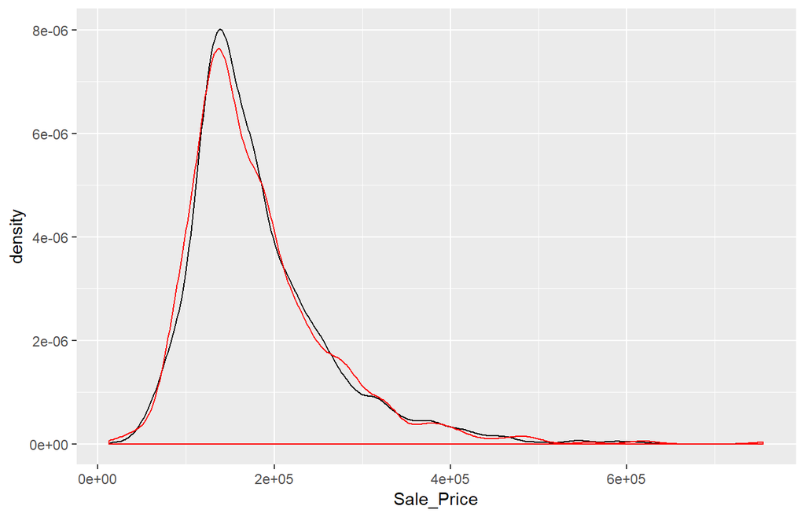

```r
ggplot(train_1,aes(x=Sale_Price))+
  geom_density(trim=TRUE)+
  geom_density(data=test_1, trim=T, col="red")
```

To normalize, we have two options:

**Option 1**: normalize with a __log transformation_._ This will transform most right skewed distributions to be approximiately normal.

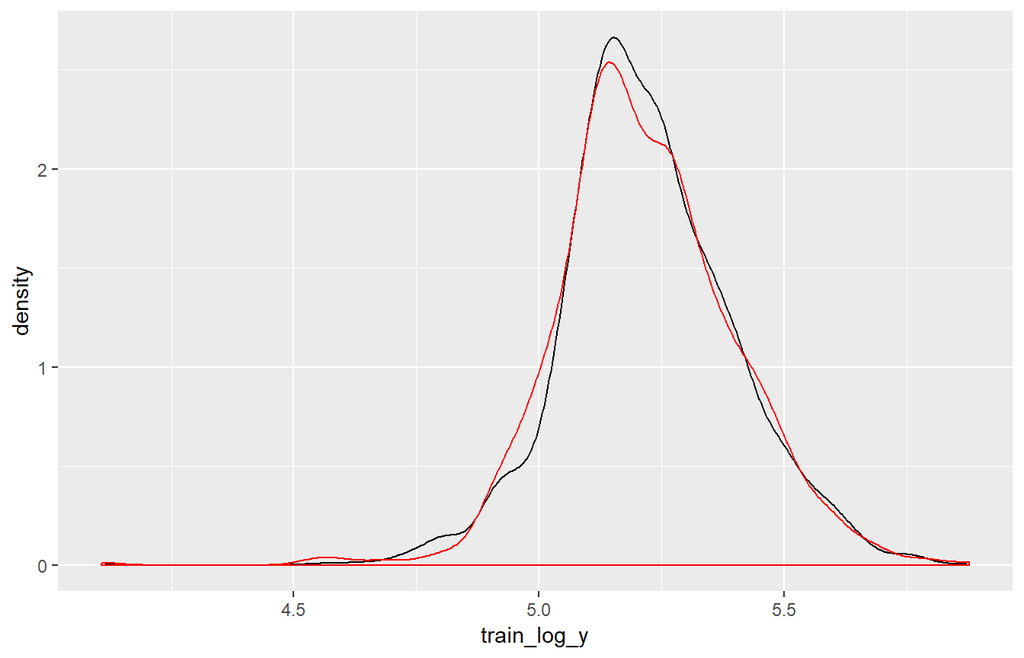

```r
# log transformation
train_log_y <- log10(train_1$Sale_Price)
test_log_y <- log10(test_1$Sale_Price)

log_transform <- ggplot(data = tibble(train_log_y), aes(train_log_y))+
  geom_density(trim=TRUE)+
  geom_density(data=tibble(test_log_y),aes(test_log_y), trim=T, col="red")
log_transform
```

**Option 2**: use a **Box Cox transformation**.

A Box Cox transformation is more flexible and will find the transformation from a family of power transformations that will transform the variable as close as possible to a normal distribution.

**Important notes**: be sure to compute the `lambda` on the training set and apply that same `lambda` to both the training and test set to minimize data leakage.

```r
# Box cox transformation
lambda <- forecast::BoxCox.lambda(train_1$Sale_Price)
train_bc_y <- forecast::BoxCox(train_1$Sale_Price, lambda)
test_bc_y <- forecast::BoxCox(test_1$Sale_Price, lambda)
```

We can see that in this example, the log transformation and Box Cox transformation both do about equally well in transforming our response variable to be normally distributed.

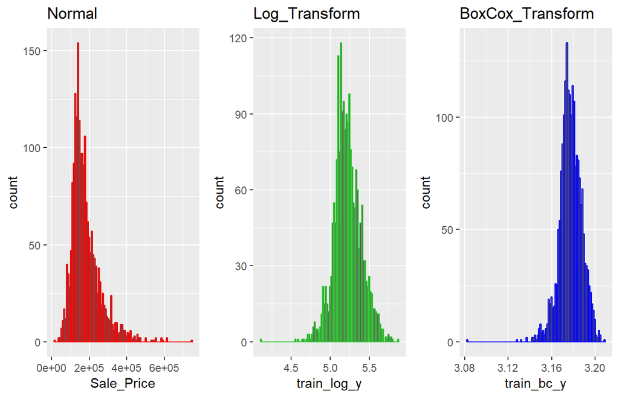

```r
p1 <- ggplot(data=train_1, aes(Sale_Price))+
  geom_histogram(bins=100, col="red")+
  ggtitle("Normal")

p2 <- ggplot(data = tibble(train_log_y), aes(train_log_y))+
  geom_histogram(bins=100, col="lime green")+
  ggtitle("Log_Transform")

p3 <- ggplot(data=tibble(train_bc_y), aes(train_bc_y))+
  geom_histogram(bins=100,col="blue")+
  ggtitle("BoxCox_Transform")

gridExtra::grid.arrange(p1,p2,p3, nrow=1)
```

Note that when you model with a transformed response variable, your predictions will also be in the transformed value. You will likely want to re-transform your predicted values back to their normal state so that decision-makers can interpret the results. The following code can do this for you:

```r
# log transform a value
y <- log(10)

# re-transforming the log-transformed value
exp(y)
```

```
## [1] 10
```

```r
# Box Cox transform a value
y <- forecast::BoxCox(10, lambda)
y
```

```
## [1] 1.651249
## attr(,"lambda")
## [1] -0.3067918
```

```r
# forecast::BoxCox

# inverse Box Cox function
inv_box_cox <- function(x,lambda){
  if (lambda==0) exp(x) else (lambda*x+1)^(1/lambda)
}

# re-transfrming the Box Cox transform value
inv_box_cox(y, lambda)
```

```
## [1] 10
## attr(,"lambda")
## [1] -0.3067918
```

##### 2.1.1.3.2 Predictor transformation

Some models such as K-NN, SVMs, PLS, neural networks require that the features have the same units. **Centering** and **scaling** can be used for this purpose and is often refered to as **standardizing** the features. Standardizing numeric variables results in zero mean and unit variance, which provides a common comparable unit of measure across all the variables.

Some packages have built^in arguments (i.e., `h20`, `caret`) to standardize and some do not (ie., `glm`, `keras`). IF you need to manually standardize your variables you can use the `preProcess` function provided by the `caret` package.

For example, here we center and scale our predictor variables. Note, it is important you standardize the test data based on the training mean and variance values of each feature. This minimizes data leakage.

```r
# identify only the predictor variables
features <- setdiff(names(train_1), "Sale_Price")

# pre-process estimation based on training features
pre_process <- caret::preProcess(
  x = train_1[,features],
  method = c("center", "scale")
)

# apply to both training & test
train_x <- predict(pre_process, train_1[, features])
test_x <- predict(pre_process, test_1[,features])
```

##### 2.1.1.3.3 Alternative feature transformation

There are some alternative transformations that you can perform:

- Normalizing the predictor variables with a *Box Cox transformation* can improve parametric model performance.
- Collapsing highly correlated variables with *PCA* can reduce the number of features and increase the stability of generalize linear models. However, this reduces the amount of information at your disposal and future tutorials show you how to use regularization as a better alternative to PCA.
- Removing *near-zero* or *zero variance variables*. Variables with vary little variance tend to not improve model performance and can be removed.
- preProcess provides other options which you can read more about [here](https://topepo.github.io/caret/pre-processing.html).

```r
# identify only the predictor variables
features <- setdiff(names(train_1), "Sale_Price")

# pre-process estimation based on training features
pre_process <- preProcess(
  x      = train_1[, features],
  method = c("center", "scale", "pca", "nzv")
  )

# apply to both training & test
train_x <- predict(pre_process, train_1[,features])
test_x <- predict(pre_process, test_1[, features])
```

#### 2.1.1.4 Basic mddel formulation

There are **many** packages to perform machine learning and there are always more than one to perform each algorithm (i.e., there are over 20 packages to perform random forests). There are pros/cons to each package; some nay be more computationally efficient while other may have more hyperparameter tuning options.

Future tutorials will expose you to several packages; some that have become “the standard” and others that are new and may be considered “maturing”. Just realize there are more ways than one to skin.

For example, these three functions will all produce the samme linear regression model output:

```r
lm.lm <- lm(Sale_Price~., data = train_1)
lm.glm <- glm(Sale_Price~., data=train_1, family=gaussian)
lm.caret <- caret::train(Sale_Price ~., data=train_1, method = "lm")

lm_multiple_package = tibble(
  model = c("lm", "glm", "caret"),
  outcome = list(lm.lm, lm.glm, lm.caret)
)

# test <- "abcde"
# stringr::str_sub(test, 1,3)

lm_multiple_package$outcome[[1]] %>%
  broom::tidy() %>%
  ggplot(aes(stringr::str_sub(term, 1, 3), estimate, col=p.value<0.01))+
  geom_point()+
  coord_flip()

# lm_multiple_package %>%
#   mutate( outcome_tidy = purrr::map(outcome, broom::tidy))
```

[output not shown]

One thing you will notice throughout future tutotiral s is that we can specify our model formulation in different ways. In the above examples, we use the model formulation (`Sale_Price`, which says explain `Sale_Price` based on all features) approach. Alternative approaches include the matrix formulation and variable name specification approaches.

*Matrix formulation* requires that we separate our response variable from our features. For example, in the regularization tutorial we will use `glmnet` which requires our features `x` and response `y` to be specified separately:

```r
# get feature names
features <- setdiff(names(train_1), "Sale_Price")

# create feature and response set
train_x <- train_1[, features]
train_y <- train_1$Sale_Price

# example of matrix formulation
library(glmnet)
glmnet.m1 <- glmnet(x = train_x, y = train_y)
```

Alternatively, `h2o` uses *variable name specification* where we provide all the data combined in one `training_frame` but we specify the features and response with character strings:

```r
# create variable names and h2o training frame
h2o.init()
```

[output not shown]

```r
y <- "Sale_Price"
x <- setdiff(names(train_1), y)
train.h2o <- as.h2o(train_1)

# example of variable name specification
h20.m1 <- h2o.glm(x=x, y=y, training_frame = train.h2o)
```